# Моментум-стратегии и reality check Россия

> Количество исследумых компаний – **49**

> Период отслеживания менялся от **1** до **12** месяцев

> Период ожидания менялся от **0** до **8** недель

> Период инвестирования менялся от **1** до **12** месяцев

## 1. Моментум стратегии при равных весах. Ранжирование по средней доходности (бенчмарк 6% годовых - только для reality check)

> Всего было рассмотрено **5184** стратегий

#### **Таблица 1. Все стратегии**

|  | mean | t | p-value | hist_per | moment_per | invest_per | percent | Amount_of_negative |
| --- | --- | --- | --- | --- | --- | --- | --- | --- |
| 1 | 0.000638 | 0.328836 | 0.742396 | 4 | 0 | 4 | 0.5 | 284 |
| 2 | 0.000878 | 0.596673 | 0.550954 | 4 | 0 | 8 | 0.5 | 290 |
| 3 | 0.00278 | 2.26861 | 0.023651 | 4 | 0 | 12 | 0.5 | 273 |
| 4 | 0.002486 | 2.221301 | 0.026708 | 4 | 0 | 16 | 0.5 | 277 |
| 5 | 0.003142 | 2.891659 | 0.003973 | 4 | 0 | 20 | 0.5 | 269 |
| 6 | 0.002352 | 1.669714 | 0.095505 | 4 | 0 | 24 | 0.5 | 253 |
| 7 | -0.001078 | 0.519679 | 0.603482 | 4 | 0 | 28 | 0.5 | 250 |
| 8 | -0.002259 | 0.902337 | 0.367245 | 4 | 0 | 32 | 0.5 | 245 |
| 9 | -0.001463 | 0.50431 | 0.614231 | 4 | 0 | 36 | 0.5 | 243 |
| 10 | -0.005355 | 1.613212 | 0.107231 | 4 | 0 | 40 | 0.5 | 250 |

[output cut: 5174 more lines]

#### **Рисунок 1.**

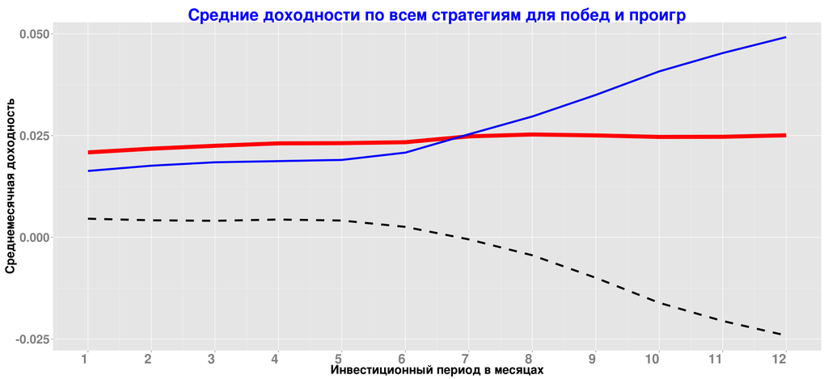

#### **Таблица 2. Агрегированные по всем стратегиям доходности победителей и проигравших**

|  | invest.per | aggr.winner | aggr.loser | delta |
| --- | --- | --- | --- | --- |
| 1 | 1 | 0.0209 | 0.0163 | 0.0046 |
| 2 | 2 | 0.0218 | 0.0176 | 0.0042 |
| 3 | 3 | 0.0225 | 0.0184 | 0.0041 |
| 4 | 4 | 0.0231 | 0.0187 | 0.0044 |
| 5 | 5 | 0.0231 | 0.019 | 0.0041 |
| 6 | 6 | 0.0234 | 0.0208 | 0.0026 |
| 7 | 7 | 0.0248 | 0.0253 | -0.0005 |
| 8 | 8 | 0.0253 | 0.0297 | -0.0044 |
| 9 | 9 | 0.025 | 0.035 | -0.0099 |
| 10 | 10 | 0.0247 | 0.0408 | -0.0161 |

[output cut: 2 more lines]

> Лучшая по средней доходности стратегия дает среднемесячную доходность **2.64** **%** и имеет параметры: период отбора – **2** месяцев, период ожидания – **5** недель, период инвестирования – **7** месяцев, процентиль – **0.1**

> Bootstrap p-value равен **0.844**

> Всего портфелей у лучшей стратегии – **593** Количество отрицательных доходностей у лучшей стратегии – **243** ( **40.98%** )

#### **Рисунок 2.**

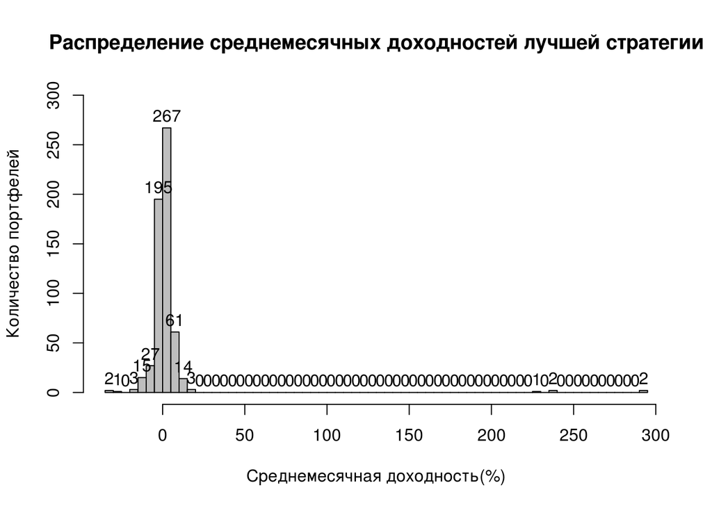

#### **Рисунок 3. (вертикальные пунктирные линии - начало нового года)**

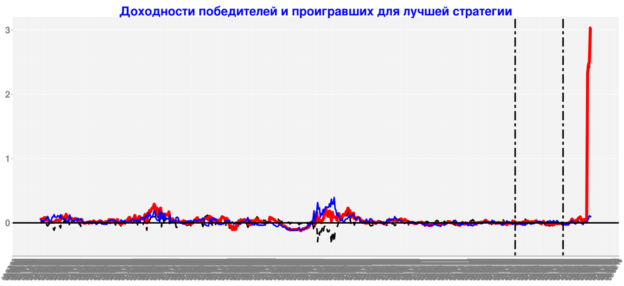

#### **Таблица 3. Доходности победителей и проигравших для лучшей стратегии**

|  | date | Win_portf | Los_portf | Win_Los |
| --- | --- | --- | --- | --- |
| 1 | 2003-02-03 | 0.0412 | 0.0467 | -0.0055 |
| 2 | 2003-02-10 | 0.0588 | 0.0427 | 0.0161 |
| 3 | 2003-02-17 | 0.0603 | 0.0264 | 0.0339 |
| 4 | 2003-02-24 | 0.0551 | 0.0376 | 0.0175 |
| 5 | 2003-03-03 | 0.0773 | 0.0248 | 0.0525 |
| 6 | 2003-03-10 | 0.0813 | 0.0323 | 0.0489 |
| 7 | 2003-03-17 | 0.077 | 0.0587 | 0.0183 |
| 8 | 2003-03-24 | 0.041 | 0.0753 | -0.0343 |
| 9 | 2003-03-31 | 0.0513 | 0.0997 | -0.0485 |
| 10 | 2003-04-07 | 0.0406 | 0.0677 | -0.0271 |

[output cut: 583 more lines]

### **Вхождение в победителей и проигравших для лучшей стратегии**

#### **Рисунок 4.**

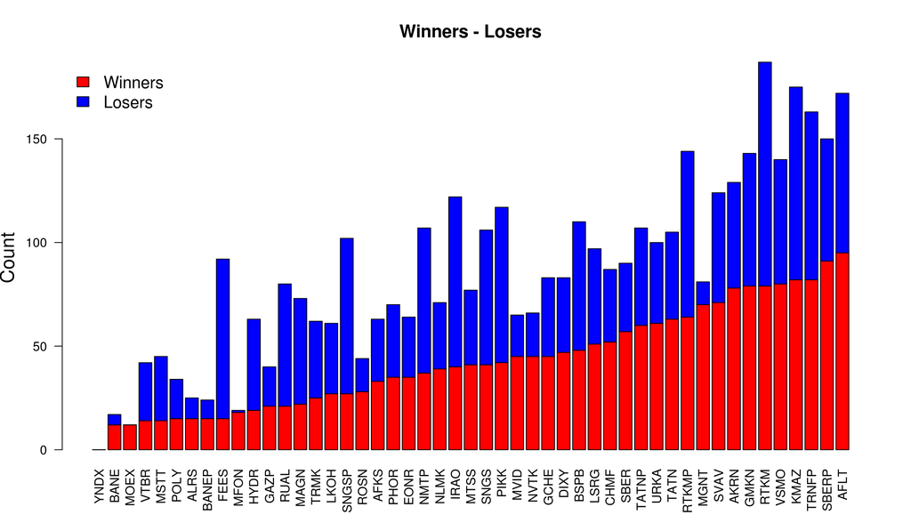

#### **Рисунок 5.**

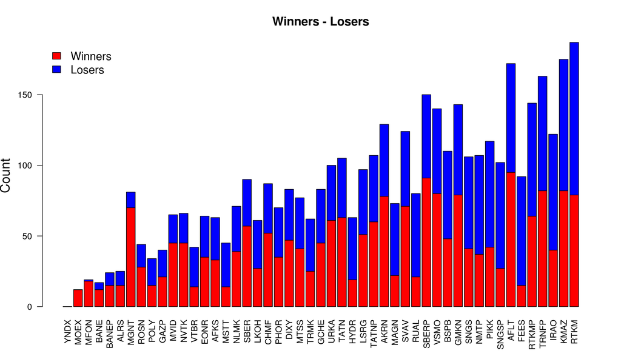

#### **Таблица 4. Вхождение компаний в победители и проигравшие для лучшей по средней доходности стратегии**

|  | Ticket | In_winners | In_losers |
| --- | --- | --- | --- |
| 1 | POLY | 15 | 19 |
| 2 | YNDX | 0 | 0 |
| 3 | ALRS | 15 | 10 |
| 4 | AKRN | 78 | 51 |
| 5 | AFLT | 95 | 77 |
| 6 | BSPB | 48 | 62 |
| 7 | BANE | 12 | 5 |
| 8 | BANEP | 15 | 9 |
| 9 | VTBR | 14 | 28 |
| 10 | VSMO | 80 | 60 |

[output cut: 39 more lines]

## 2. Моментум стратегии при равных весах. Ранжирование по t-статистике (бенчмарк 6% годовых - только для reality check)

> Лучшая по t-статистике стратегия дает среднемесячную доходность **-2.57** **%** и имеет параметры: период отбора – **12** месяцев, период ожидания – **8** недель, период инвестирования – **12** месяцев, процентиль – **0.5**

> Bootstrap p-value равен **0.84**

> Всего портфелей у лучшей по t-статистике стратегии – **593** Количество отрицательных доходностей у лучшей по t-статистике стратегии – **352** ( **59.36%** )

#### **Рисунок 6.**

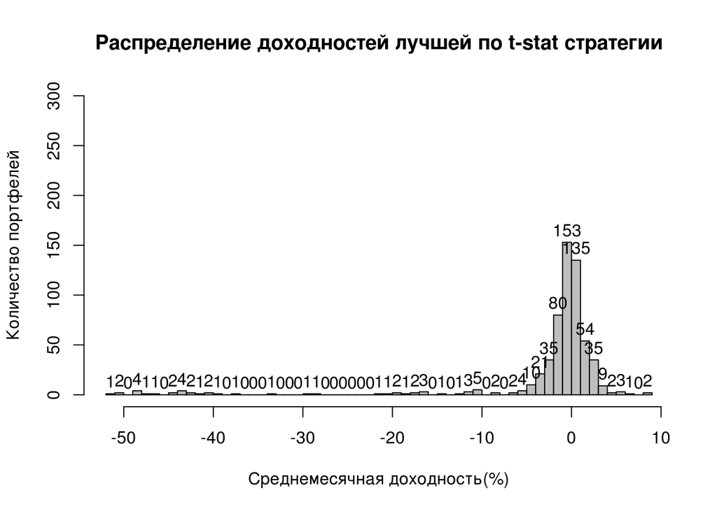

#### **Рисунок 7. (вертикальные пунктирные линии - начало нового года)**

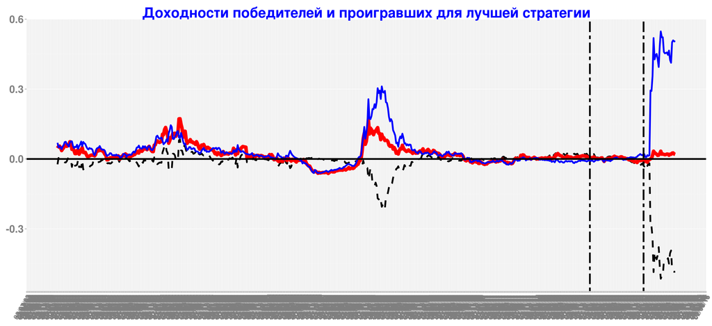

#### **Таблица 5. Доходности победителей и проигравших для лучшей стратегии**

|  | date | Win_portf | Los_portf | Win_Los |
| --- | --- | --- | --- | --- |
| 1 | 2003-02-03 | 0.0465 | 0.0695 | -0.023 |
| 2 | 2003-02-10 | 0.0537 | 0.0494 | 0.0043 |
| 3 | 2003-02-17 | 0.0553 | 0.0552 | 0 |
| 4 | 2003-02-24 | 0.0484 | 0.0489 | -0.0005 |
| 5 | 2003-03-03 | 0.0361 | 0.0421 | -0.006 |
| 6 | 2003-03-10 | 0.0426 | 0.0539 | -0.0113 |
| 7 | 2003-03-17 | 0.0485 | 0.0596 | -0.0111 |
| 8 | 2003-03-24 | 0.0579 | 0.0723 | -0.0145 |
| 9 | 2003-03-31 | 0.0588 | 0.0738 | -0.0151 |
| 10 | 2003-04-07 | 0.0543 | 0.0641 | -0.0097 |

[output cut: 583 more lines]

### **Вхождение в победителей и проигравших для лучшей стратегии**

#### **Рисунок 8.**

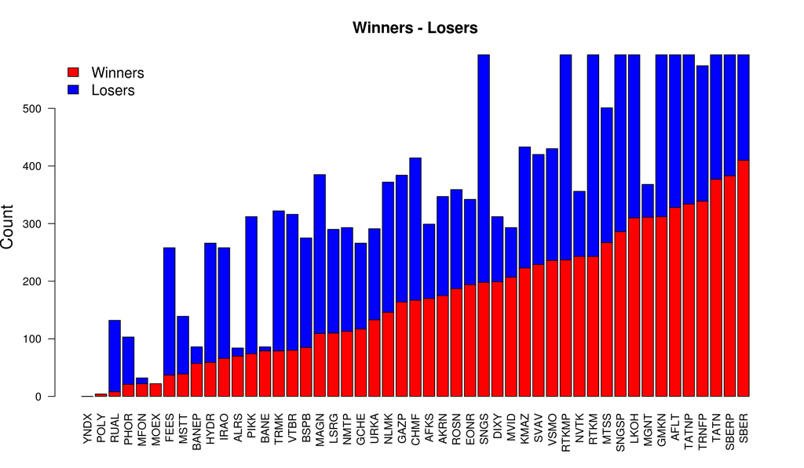

#### **Рисунок 9.**

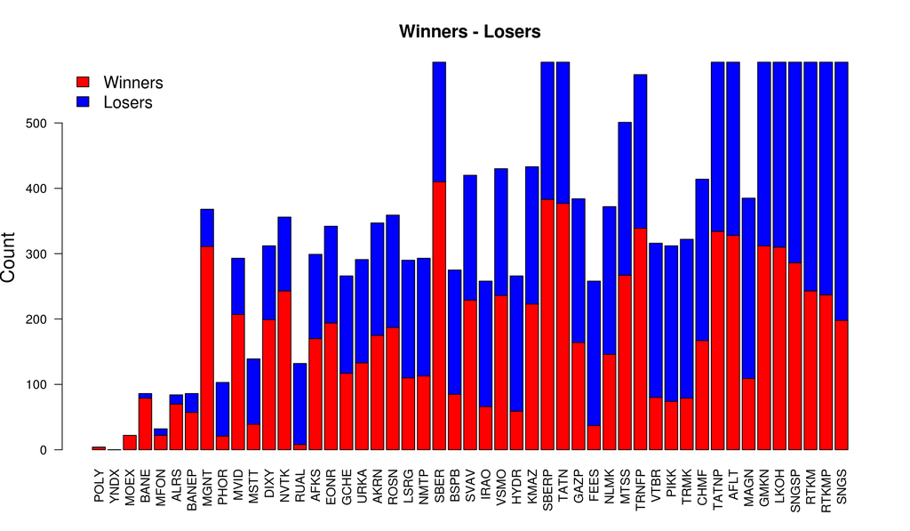

#### **Таблица 6. Вхождение компаний в победители и проигравшие для лучшей по t-статистике стратегии**

|  | Ticket | In_winners | In_losers |
| --- | --- | --- | --- |
| 1 | POLY | 4 | 0 |
| 2 | YNDX | 0 | 0 |
| 3 | ALRS | 70 | 14 |
| 4 | AKRN | 175 | 172 |
| 5 | AFLT | 328 | 265 |
| 6 | BSPB | 85 | 190 |
| 7 | BANE | 79 | 7 |
| 8 | BANEP | 57 | 29 |
| 9 | VTBR | 80 | 236 |
| 10 | VSMO | 236 | 194 |

[output cut: 39 more lines]